# Plots

## Análise de Dataset - Atividade ML

### Instruçães 01: Carregando os dados

O dataset tem 2,075,259 registros

- Dados de dezembro de 2006 e novembro de 2010 (47 meses)
- Vamos usar apenas 1 mês. fevereiro de 2007

Quanto de memória é necessário para carregar o dataset? confira depois com object.size)

```r
12 * 9 * 2075259
```

```
[1] 224127972
```

```r
file.size("../data/household_power_consumption.txt.gz")
```

```
[1] 17202128
```

Este dataset possui missing values. Eles estão registrados como “?”

```r
file <- gzfile("../data/household_power_consumption.txt.gz")
all_data <- read.table(file, header = T, sep = ";", na.strings = "?")
object.size(all_data)
```

```
133026752 bytes
```

```r
library(lubridate)
```

Converte o campo de data pois iremos usar no filtro (com lubridate)

```r
all_data$datetime <- dmy_hms( paste(all_data$Date, all_data$Time))
all_data$Date <- dmy(all_data$Date)
all_data$Time <- hms(all_data$Time)
object.size(all_data)
```

```
249035080 bytes
```

Filtra o mês de trabalho:

```r
data = filter(all_data, all_data$Date >=ymd("2007-02-01" ) & all_data$Date < ymd("2007-03-01" ))
data2 = filter(all_data, all_data$Date >=ymd("2009-02-01" ) & all_data$Date < ymd("2009-03-01" ))
```

```r
summary(all_data)
```

```
      Date                 Time                           Global_active_power Global_reactive_power
 Min.   :2006-12-16   Min.   :0S                          Min.   : 0.076      Min.   :0.000
 1st Qu.:2007-12-12   1st Qu.:6H 0M 0S                    1st Qu.: 0.308      1st Qu.:0.048
 Median :2008-12-06   Median :12H 0M 0S                   Median : 0.602      Median :0.100
 Mean   :2008-12-05   Mean   :11H 59M 32.7448092021295S   Mean   : 1.092      Mean   :0.124
 3rd Qu.:2009-12-01   3rd Qu.:18H 0M 0S                   3rd Qu.: 1.528      3rd Qu.:0.194
 Max.   :2010-11-26   Max.   :23H 59M 0S                  Max.   :11.122      Max.   :1.390
                                                          NA's   :25979       NA's   :25979
    Voltage      Global_intensity Sub_metering_1   Sub_metering_2   Sub_metering_3
 Min.   :223.2   Min.   : 0.200   Min.   : 0.000   Min.   : 0.000   Min.   : 0.000
 1st Qu.:239.0   1st Qu.: 1.400   1st Qu.: 0.000   1st Qu.: 0.000   1st Qu.: 0.000
 Median :241.0   Median : 2.600   Median : 0.000   Median : 0.000   Median : 1.000
 Mean   :240.8   Mean   : 4.628   Mean   : 1.122   Mean   : 1.299   Mean   : 6.458
 3rd Qu.:242.9   3rd Qu.: 6.400   3rd Qu.: 0.000   3rd Qu.: 1.000   3rd Qu.:17.000
 Max.   :254.2   Max.   :48.400   Max.   :88.000   Max.   :80.000   Max.   :31.000
 NA's   :25979   NA's   :25979    NA's   :25979    NA's   :25979    NA's   :25979
    datetime
 Min.   :2006-12-16 17:24:00
 1st Qu.:2007-12-12 00:18:30
 Median :2008-12-06 07:13:00
 Mean   :2008-12-06 07:13:00
 3rd Qu.:2009-12-01 14:07:30
 Max.   :2010-11-26 21:02:00
```

### Instruções 02: Histograma de consumo

Fazer um histograma da coluna Global_active_power

Explique a frequência concentração do consumo

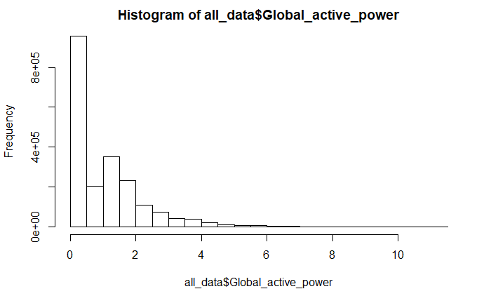

```r
hist( all_data$Global_active_power )
```

### Instruções 03: Variação de consumo

Fazer um gráfico de linhas do período.

- Há algum período com características de consumo que chamam a atenção?
- Faça um gráfico de linhas de 2 dias (01-fev a 02-fev)
- Há alguma característica no consumo de energia ao longo do tempo?

OBS: 1 mês de 2007, 2 dias de 2007; 1 mês de 2009, 2 dias de 2009;

```r
data_2dias = filter(all_data, all_data$Date >=ymd("2009-02-01" ) & all_data$Date < ymd("2009-02-02" ))
hist( data_2dias$Global_active_power )
```

```
Error in data_2dias$Global_active_power :
  $ operator is invalid for atomic vectors
```

### Instruções 04: Variação de consumo por medida

O que são as colunas: sub_metering_01, 02 e 03?

Faça o mesmo gráfico de 2 dias e avalie a variação destes dados.

Adicione uma legenda com o comando legend

```r
legend("topright", col=c("black", "red", "blue"),
       lty=1, lwd=2,
       legend=c("Sub_metering_1",
                "Sub_metering_2",
                "Sub_metering_3"))
```

```
Error in strwidth(legend, units = "user", cex = cex, font = text.font) :
  plot.new has not been called yet
```

### Instruções 05: Multi plotagem

Construa uma plotagem com 4 gráficos:

### Final

Fazer um gráfico de consumo por ano para cada ano da série.

Fazer um histograma de todos os meses para 2006, 2007, 2008, 2009 e 2010.

Fazer um box-plot

Graus decimais (DD) expressa latitude e longitude coordenadas geográficas como frações decimais e são usadas em vários aplicativos Sistema de informação

https://pt.wikipedia.org/wiki/Graus_decimais

## Plots de senos e cossenos

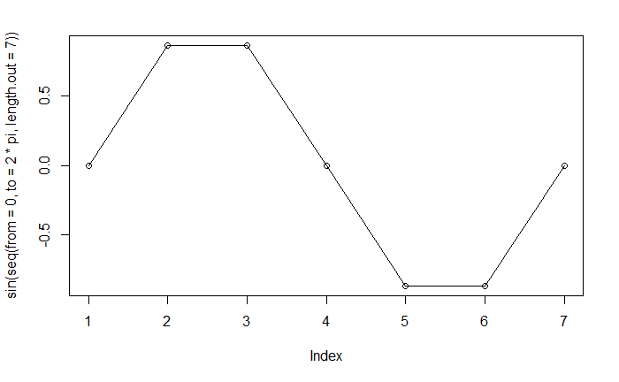

```r
plot( sin(seq(from = 0, to = 2*pi, length.out = 7 )), type = 'o')
```

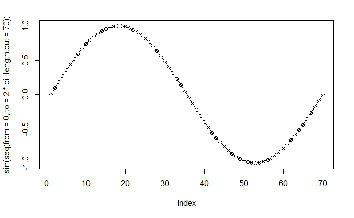

```r
plot( sin(seq(from = 0, to = 2*pi, length.out = 70 )), type = 'o' )
```

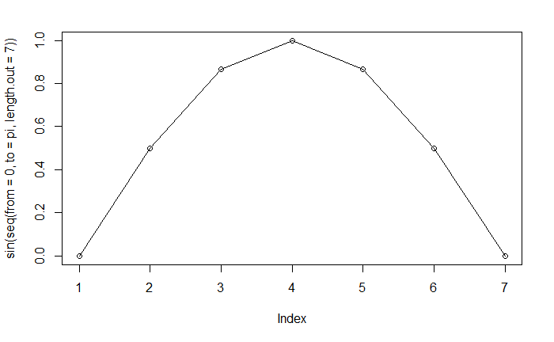

```r
plot( sin(seq(from = 0, to = pi, length.out = 7 )), type = 'o')
```

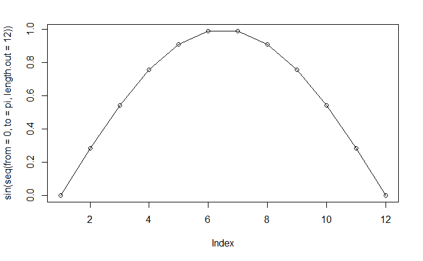

```r
plot( sin(seq(from = 0, to = pi, length.out = 12 )), type = 'o' )
```

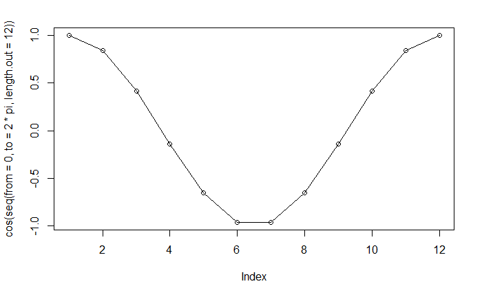

```r
plot( cos(seq(from = 0, to = 2*pi, length.out = 12 )), type = 'o' )
```

## Finalização da modelagem

- Desenhar um modelo de regressão linear multivariada.
- Considerar todas as plotagens realizadas.
- Qual o erro total esperado da predição?
- Qual o desvio padrão do erro obtido?
- Você sabe qual o P-Valor e R2 do modelo?
- Que variáveis não estão disponíveis que você incluiria no modelo?